# Final Project: Conditions Contributing To Deaths Involving Coronavirus Disease-2019 (COVID-19), By Age Group, In The United States

08/10/2020

# Loading Packages:

My initial step was to load all the required packages using the library() function. I used four main packages: readr, dplyr, tidyverse and, ggplot2.

# About The Dataset:

The dataset used in my project was taken from the HealthData.gov website. It is titled “Conditions contributing to deaths involving coronavirus disease 2019 (COVID-19), by age group,in the United States.” I chose this dataset because there are still so many unanswered questions as to who is susceptible to this disease. I wanted to dissect this dataset to garner further insight. It contains 23 observations with 15 variables. The 23 observations contains different diseases and the number of people that have succumbed to COVID-19, having a specific co-morbidity. The 15 variables include all the different age groups, the ICD-10 codes and the timeline of data collected.

To load, I used the read_csv(“filename”) function from the readr package. I viewed the dataset using the head(x,….) function from the utils package.

```
## # A tibble: 6 x 15
##   `Data as of` `Start Week` `End Week` `Condition Grou… Condition ICD10_codes
##   <chr>        <chr>        <chr>      <chr>            <chr>     <chr>
## 1 07/05/2020   02/01/2020   07/04/2020 Coronavirus Dis… Coronavi… U071
## 2 07/05/2020   02/01/2020   07/04/2020 Respiratory dis… Influenz… J09-J18
## 3 07/05/2020   02/01/2020   07/04/2020 Respiratory dis… Chronic … J40-J47
## 4 07/05/2020   02/01/2020   07/04/2020 Respiratory dis… Adult re… J80
## 5 07/05/2020   02/01/2020   07/04/2020 Respiratory dis… Respirat… J96
## 6 07/05/2020   02/01/2020   07/04/2020 Respiratory dis… Respirat… R09.2
## # … with 9 more variables: `All ages` <dbl>, `0-24 years` <dbl>, `25-34
## #   years` <dbl>, `35-44 years` <dbl>, `45-54 years` <dbl>, `55-64
## #   years` <dbl>, `65-74 years` <dbl>, `75-84 years` <dbl>, `85 years and
## #   over` <dbl>
```

# Cleaning The Dataset:

A peculiar feature of this dataset is it’s structure. Here, all the columns represent grouped data instead of individual values. This was definitely a challenge as we have worked with individual values in many of our classes. The variables that were of particular interest to me included, deaths contributed by cardiovascular and respiratory co-morbidities. These two disease groups are very common in the United States. I wanted to analyze the burden of these co-morbidities on COVID-19 related deaths and how it varied with age groups. Following were the steps performed by me to clean my dataset:

1. Analyzed the class of data using the class(x) function from the base package.
2. Removed unwanted columns using the select(data, -c(“Name of Columns”)) function from the dplyr package.
3. Selected columns/rows of interest and compiled that into a new dataframe. The “covidresp” dataframe contained only respiratory co-morbidities based on age group. Similarly, the “covidcards” dataframe contained only cardiovascular co-morbidities based on age group.
4. Converted a “horizontal” dataset into a “vertical” one using the gather(data, key, value…) function from the tidyr package. This was the most challenging step. The reason I had to do this was to ensure that all points could be represented on my final plot. The two dataframes were renamed to “longcovidresp” and “longcovidcards” respectively.
5. Removed the rows containing data “All Ages” and made it into a new dataframe as these data points had a higher maximum value compared to the rest. The dataframes were renamed to “longcovidrespnoall” and “longcovidcardsnoall” respectively.
6. The dataframe containing only the “All Ages” datapoints were named as “longcovidrespall” and “longcovidcardsall” which contained the total number of cases in both disease subsets.

```
## [1] "spec_tbl_df" "tbl_df"      "tbl"         "data.frame"
```

```
## # A tibble: 6 x 12
##   `Condition Grou… Condition ICD10_codes `All ages` `0-24 years` `25-34 years`
##   <chr>            <chr>     <chr>            <dbl>        <dbl>         <dbl>
## 1 Coronavirus Dis… Coronavi… U071            113013          174           780
## 2 Respiratory dis… Influenz… J09-J18          47050           62           360
## 3 Respiratory dis… Chronic … J40-J47           9396           10            40
## 4 Respiratory dis… Adult re… J80              16095           41           155
## 5 Respiratory dis… Respirat… J96              38327           48           255
## 6 Respiratory dis… Respirat… R09.2             2405            1            13
## # … with 6 more variables: `35-44 years` <dbl>, `45-54 years` <dbl>, `55-64
## #   years` <dbl>, `65-74 years` <dbl>, `75-84 years` <dbl>, `85 years and
## #   over` <dbl>
```

# Respiratory Co-Morbidities Subset:

```
## # A tibble: 6 x 3
##   Condition                                Age        Number
##   <chr>                                    <chr>       <dbl>
## 1 Influenza and pneumonia                  0-24 years     62
## 2 Chronic lower respiratory diseases       0-24 years     10
## 3 Adult respiratory distress syndrome      0-24 years     41
## 4 Respiratory failure                      0-24 years     48
## 5 Respiratory arrest                       0-24 years      1
## 6 Other diseases of the respiratory system 0-24 years      7
```

```
## # A tibble: 6 x 3
##   Condition                                Age      Number
##   <chr>                                    <chr>     <dbl>
## 1 Influenza and pneumonia                  All ages  47050
## 2 Chronic lower respiratory diseases       All ages   9396
## 3 Adult respiratory distress syndrome      All ages  16095
## 4 Respiratory failure                      All ages  38327
## 5 Respiratory arrest                       All ages   2405
## 6 Other diseases of the respiratory system All ages   3724
```

# Cardiovascular Co-Morbidities Subset:

```
## # A tibble: 6 x 3
##   Condition              Age         Number
##   <chr>                  <chr>        <dbl>
## 1 Hypertensive diseases  0-24 years      10
## 2 Ischemic heart disease 0-24 years       2
## 3 Cardiac arrest         0-24 years      30
## 4 Cardiac arrhythmia     0-24 years       4
## 5 Heart failure          0-24 years       2
## 6 Hypertensive diseases  25-34 years     66
```

```
## # A tibble: 5 x 3
##   Condition              Age      Number
##   <chr>                  <chr>     <dbl>
## 1 Hypertensive diseases  All ages  24183
## 2 Ischemic heart disease All ages  12125
## 3 Cardiac arrest         All ages  14789
## 4 Cardiac arrhythmia     All ages   6676
## 5 Heart failure          All ages   7351
```

# Plotting:

I used the ggplot2 package to plot my cleaned dataset. Following were the steps performed by me to plot the dataset:

1. Selected my dataframe.
2. Using the ggplot(dataframe, aes(x, y, fill)….) function from the ggplot2 package, I plotted age groups on the x-axis and number on the y axis. I used a bar plot using the geom_bar(stat = “identity”, position = “dodge2”) to map the values on it and place it next to each other for comparison.
3. Made aesthetic changes using the theme(….) function. Added a title along with labels using the ggtile() and the labs() function from the ggplot2 package.
4. Adjusted dimensions of the figures to make sure they fit in the HTML file. I did this by adding dpi = 90, fig.width = 20 and fig.height = 15 to the beginning of the R code chunk.

# Respiratory Co-Morbidities Plot:

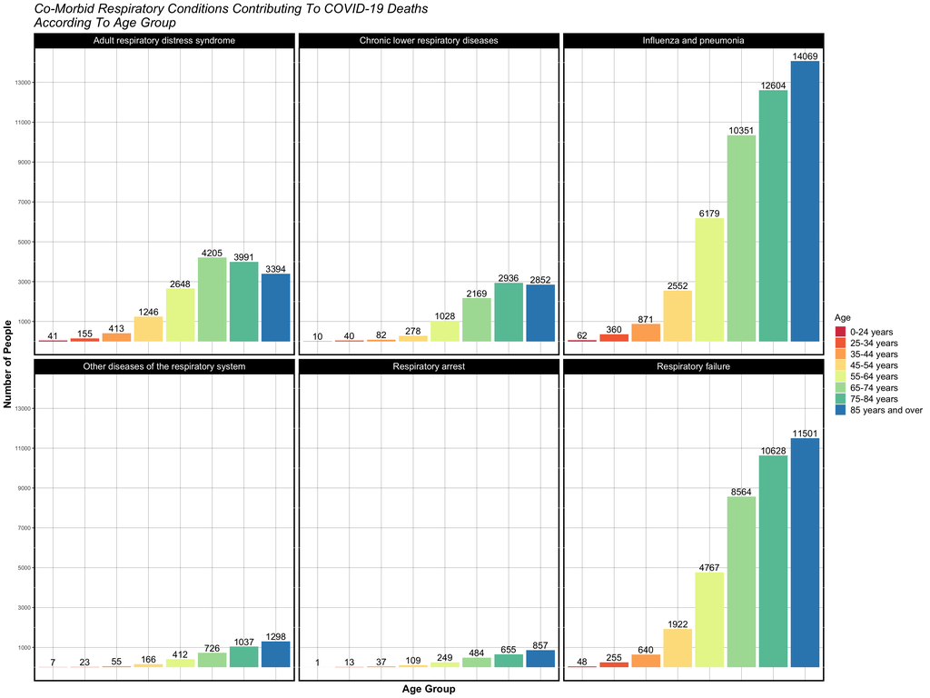

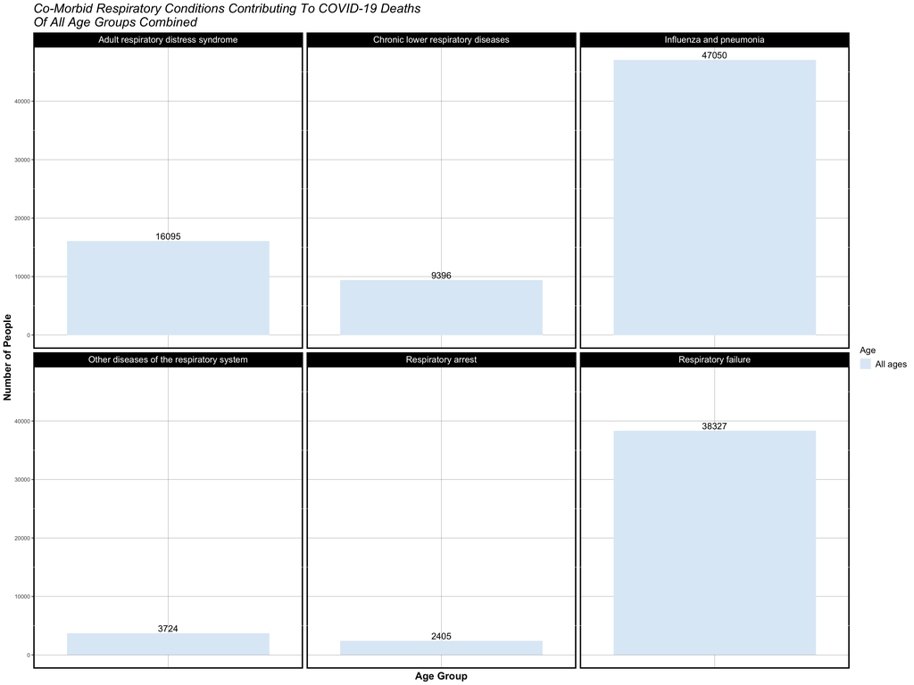

# Results and Future Direction:

From the resulting plot, we can visualize that Influenza and Pneumonia along with Respiratory Failure are the two most common co-morbid conditions in patients that have died from COVID-19. Also, this was predominant in the older population (Age group 85 years and above). One question that arises is whether the flu season will put this subset of population at even more risk of developing serious COVID-19 related complications. Respiratory failure is a general term and further research has to be conducted to understand which condition/disease can lead to severe complications.

In the younger and middle aged population too, there were more COVID-19 related deaths in patients suffering from Influenza/Pneumonia and Respiratory Failure compared to the other conditions. An area of focus could be the synergistic activity of both theses viruses or virus+bacteria in individuals of all age groups.

https://www.thelancet.com/journals/lancet/article/PIIS0140-6736(20)31052-7/fulltext

# Cardiovascular Co-Morbidities Plot:

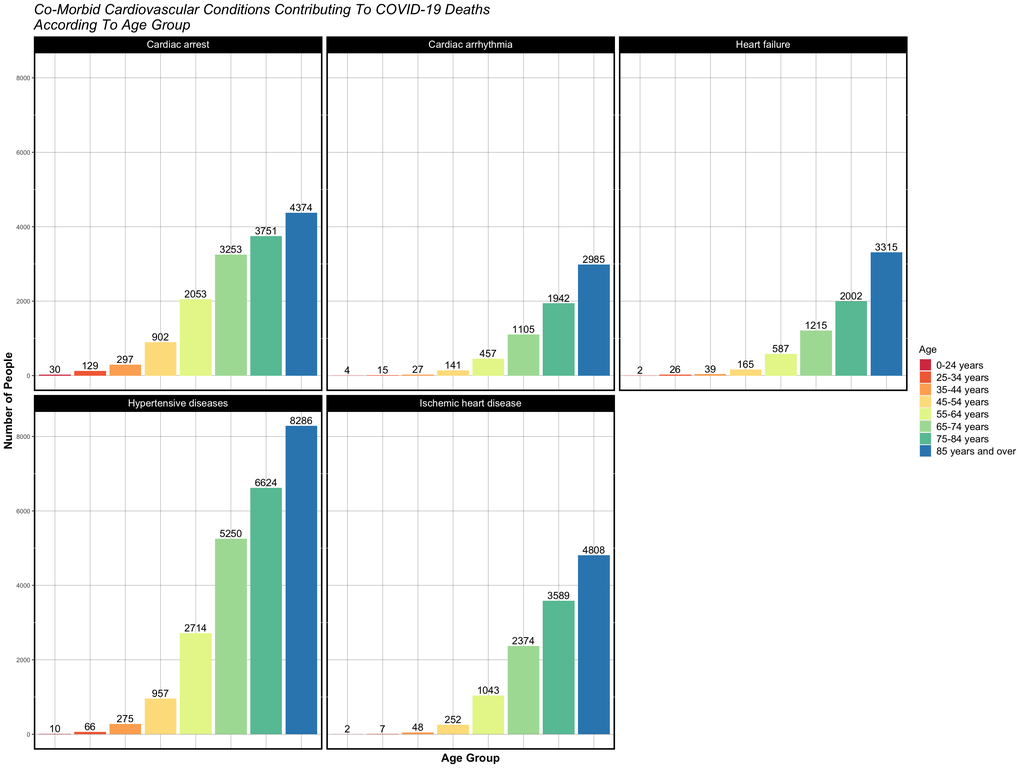

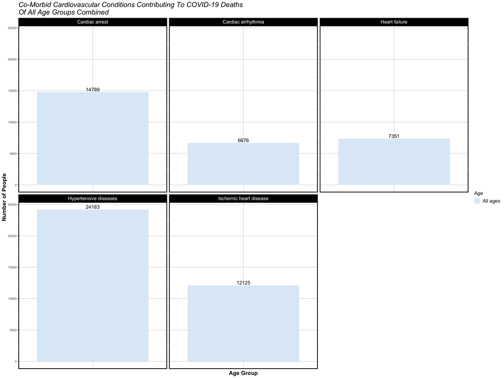

# Results and Future Direction:

From the resulting plot we can visualize that Hypertensive Diseases and Cardiac Arrest are the two most common cardiovascular co-morbid conditions in patients that died from COVID-19. This was again predominant in the older population (85 years and above). One area of focus could be to check if usage of certain anti-hypertensive medication can reduce the mortality of COVID-19 in these subset of patients. Ongoing studies are being conducted regarding the usage of ACE inhibitor, which is an anti-hypertensive medication and its effects on COVID-19 mortality, the virus also enters the lung and bloodstream via the ACE-2 receptors. However, there is still a debate due to mixed results.

https://www.clinicaltrialsarena.com/comment/ace-inhibitors-arbs-covid-19/

Also, among the younger population, COVID-19 related deaths were the highest in patients with underlying cardiac arrest compared to the rest of the conditions. Did this occur due to COVID-19 or were they reluctant to go to the hospital for treatment of their underlying condition fearing exposure? Similar results from a correspondence in NEJM showed that there was an increase out-of hospital cardiac arrests.

https://www.nejm.org/doi/full/10.1056/NEJMc2010418

Another area of further research to consider is if COVID-19 actually lead to heart related conditions or heart related conditions pre-disposed patients to develop serious consequences caused by the virus. This article by Mehra.et.al mentions that there was an increase in in-hospital deaths due to COVID-19 in patients with underlying cardiac conditions.

https://www.nejm.org/doi/full/10.1056/NEJMoa2007621

Further studies will have to be conducted to understand the COVID-19 disease characteristics and it’s pre-disposing factors, but this dataset is definitely a good foundation and a step in the right direction to address future questions.